# R Clase 3: Introducción a ggplot2

## 2.3 Componentes adicionales

Este gráfico lo podemos complementar con cambios de estadísticos o estéticos. Veamos como podemos modificarlo.

### 2.3.1 Estadísticas

El gráfico que hicimos se llama gráfico de dispersión y pretende ver la relación entre dos variables numéricas. Podemos facilitarle al usuario ver esto usando una línea de tendencia. Recuerde, todas las capas se añaden con un +

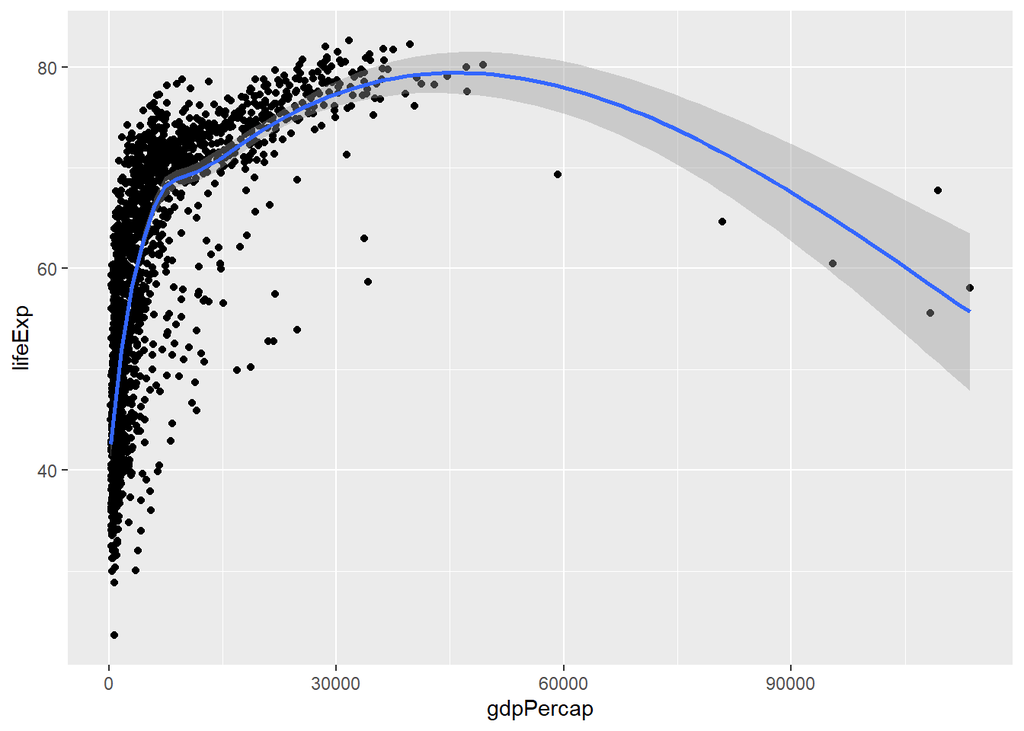

```r
ggplot(gapminder, aes(x=gdpPercap, y=lifeExp)) +
  geom_point() +
  geom_smooth() #Añadir capa con línea de tendencia
```

Para generar una línea de tendencia, es necesario que ggplot haga transformaciones estadísticas a nuestros datos, por eso a estas capas se les llama capas estadísticas.

De este se puede decir que hay una relación positiva entre el PIB promedio por persona y la expectativa de vida.

### 2.3.2 Facetas

Otro componente que se puede sumar a nuestro gráfico se llama faceta. Las facetas permiten subdividir nuestro gráfico en subgráficos de acuerdo a una variable.

En nuestro caso, estamos teniendo en cuenta todos los años al mismo tiempo, esto puede resultar confuso para nuestro público. Podemos subdividir el gráfico en años y visualizar mejor usando la función facet_wrap()

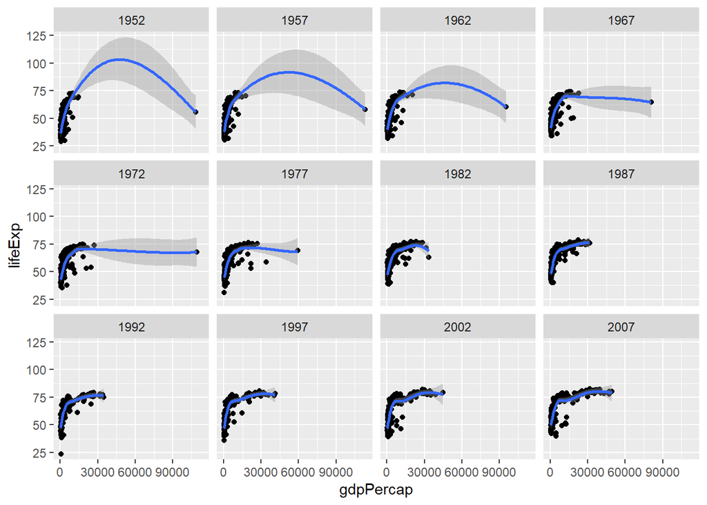

```r
ggplot(gapminder, aes(x=gdpPercap, y=lifeExp)) +
  geom_point() +
  geom_smooth() +
  facet_wrap(~year)
```

De esta manera podemos ver que si bien la expectativa de vida máxima no ha incrementado mucho, si ha aumentado el PIB per cápita. Pero todavía podemos mejorar más nuestra visualización.

Un cambio que podemos hacer es dividir el PIB entre 1000 para que no quede tan apiñado.

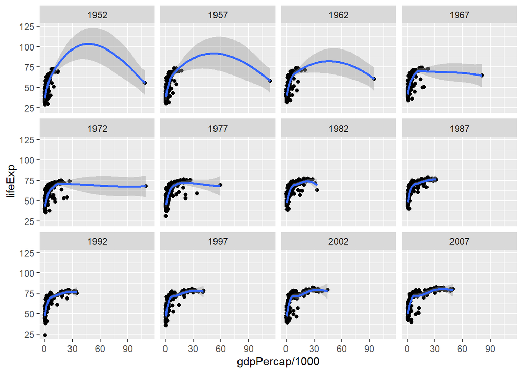

```r
ggplot(gapminder, aes(x=gdpPercap/1000, y=lifeExp)) +
  geom_point() +
  geom_smooth() +
  facet_wrap(~year)
```

### 2.3.3 Coordenadas

Las modificaciones a los ejes se pueden hacer con una variedad de funciones. Por ejemplo, lims() pone los límites para eje variable y labs() permite cambiar los nombres que aparece en el gráfico (incluso el título).

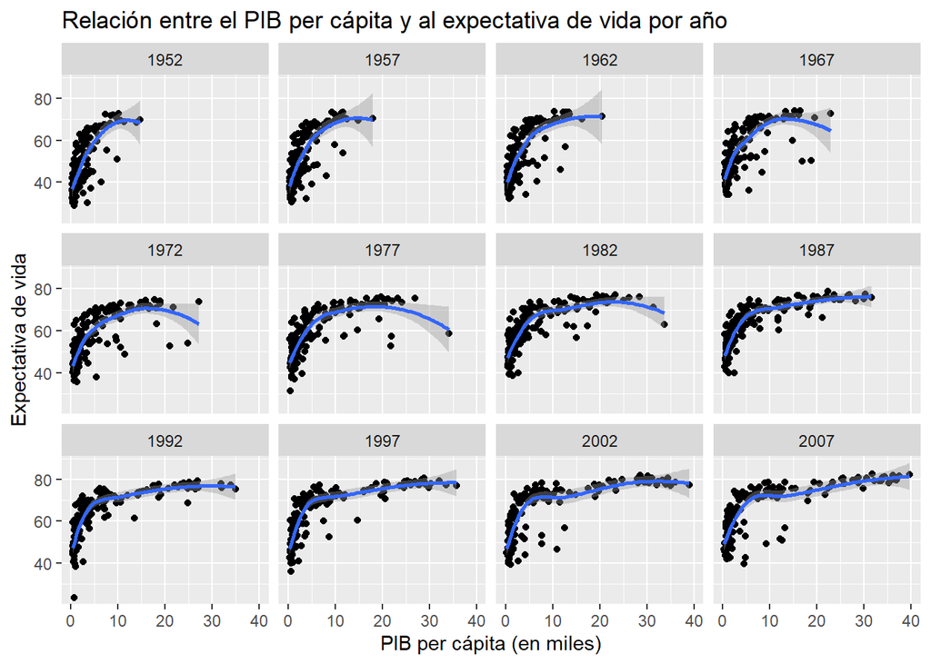

```r
ggplot(gapminder, aes(x=gdpPercap/1000, y=lifeExp)) +
  geom_point() +
  geom_smooth() +
  facet_wrap(~year) +
  lims(x = c(0,40)) +
  labs(x = 'PIB per cápita (en miles)', y = 'Expectativa de vida',
       title = 'Relación entre el PIB per cápita y al expectativa de vida por año')
```

Ya nuestro gráfico se va viendo mejor.

### 2.3.4 Temas

El último toque que le falta al gráfico es mejorar la parte estética. Para ello existe la función theme().

Si revisa el documento de ayuda (F1 o help()), se dará cuenta de que permite cambiar cada pequeño detalle del gráfico. Pero esto es abrumador, por lo que existen unos temas predeterminados que podemos probar.

Este es el tema minimal

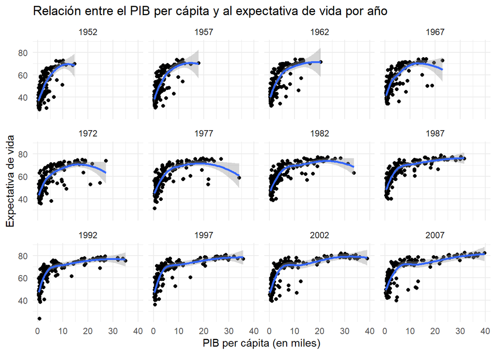

```r
ggplot(gapminder, aes(x=gdpPercap/1000, y=lifeExp)) +
  geom_point() +
  geom_smooth() +
  facet_wrap(~year) +
  lims(x = c(0,40)) +
  labs(x = 'PIB per cápita (en miles)', y = 'Expectativa de vida',
       title = 'Relación entre el PIB per cápita y al expectativa de vida por año') +
  theme_minimal()
```

Y este el tema classic

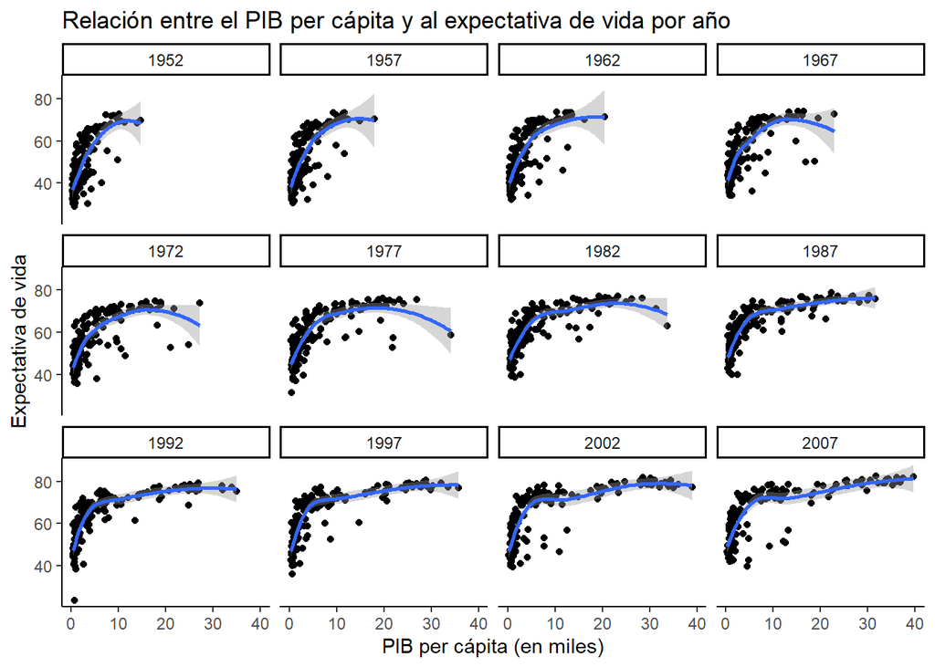

```r
ggplot(gapminder, aes(x=gdpPercap/1000, y=lifeExp)) +
  geom_point() +
  geom_smooth() +
  facet_wrap(~year) +
  lims(x = c(0,40)) +
  labs(x = 'PIB per cápita (en miles)', y = 'Expectativa de vida',
       title = 'Relación entre el PIB per cápita y al expectativa de vida por año') +
  theme_classic()
```

Hay bastantes opciones para dejar el gráfico listo para mostrar.

De esta manera, tenemos un gráfico completo y listo para mostrar en unas cuantas líneas de código.

## 2.4 Guardar

Para guardar nuestro gráfico usamos la función ggsave(). El proceso es simple, asignamos nuestro gráfico a un objeto y luego lo llamamos como primer argumento e indicamos el nombre del archivo a guardar.

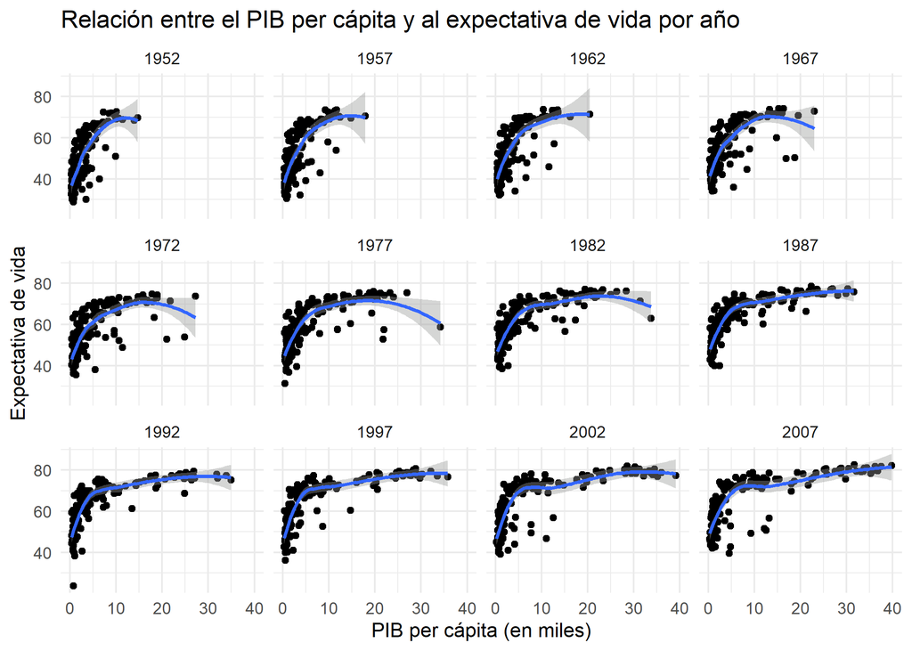

```r
grafico_puntos <- ggplot(gapminder, aes(x=gdpPercap/1000, y=lifeExp)) +
  geom_point() +
  geom_smooth() +
  facet_wrap(~year) +
  lims(x = c(0,40)) +
  labs(x = 'PIB per cápita (en miles)', y = 'Expectativa de vida',
       title = 'Relación entre el PIB per cápita y al expectativa de vida por año') +
  theme_minimal()

ggsave(grafico_puntos, file = 'grafico1.png')
```

Se puede manipular el ancho, alto y la escala del gráfico.

```r
ggsave(grafico_puntos, file = 'grafico1_1.png', width = 5, height = 5, scale = 1.3)
```

## 2.5 Geometrías más usadas

### 2.5.1 geom_bar()

Se usa para hacer gráficos de barras. El argumento stat = ‘identity’ le dice a ggplot que no modifique los datos. Esto se hace para evitar el comportamiento por defecto del geom_bar(), que es contar observaciones.

Filtraré los países de América en el año 2007 y graficaré la expectativa de vida.

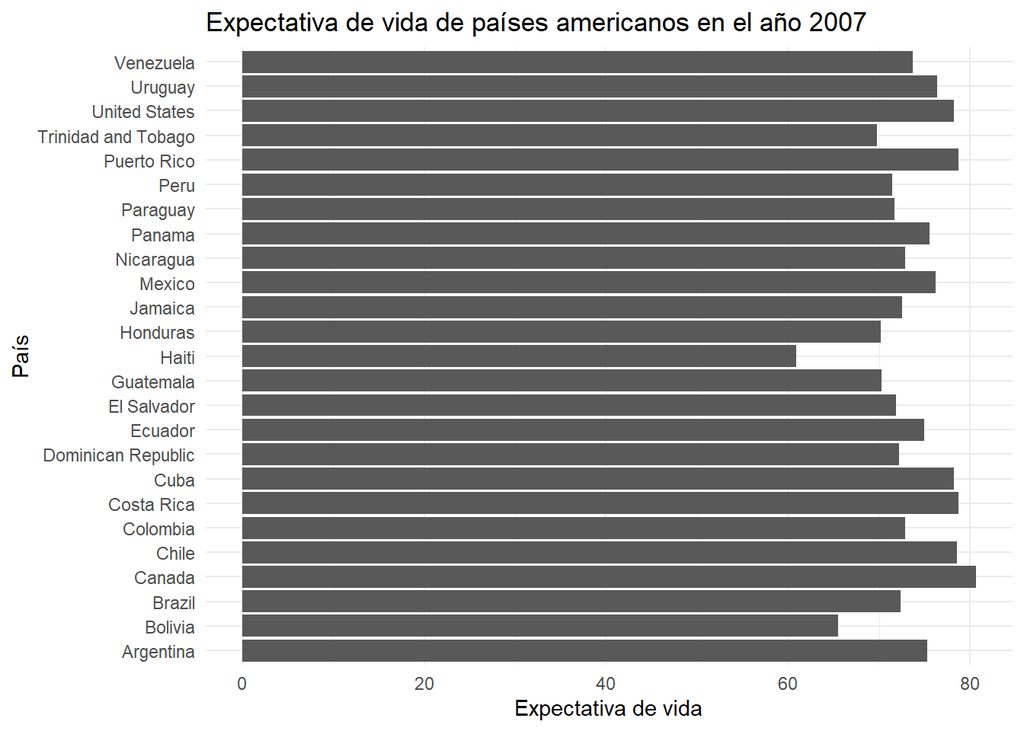

```r
df_america_2007 <- gapminder %>%
  filter(continent=='Americas' & year=='2007')

grafico_barras <- ggplot(df_america_2007, aes(x=country, y=lifeExp)) +
  geom_bar(stat = 'identity') +
  labs(x = 'País', y = 'Expectativa de vida',
       title = 'Expectativa de vida de países americanos en el año 2007') +
  coord_flip() + # Voltear el gráfico
  theme_minimal()

grafico_barras
```

Si queremos ordenarlo y cambiar el color dentro de las barras (fill), podemos usar el siguiente código

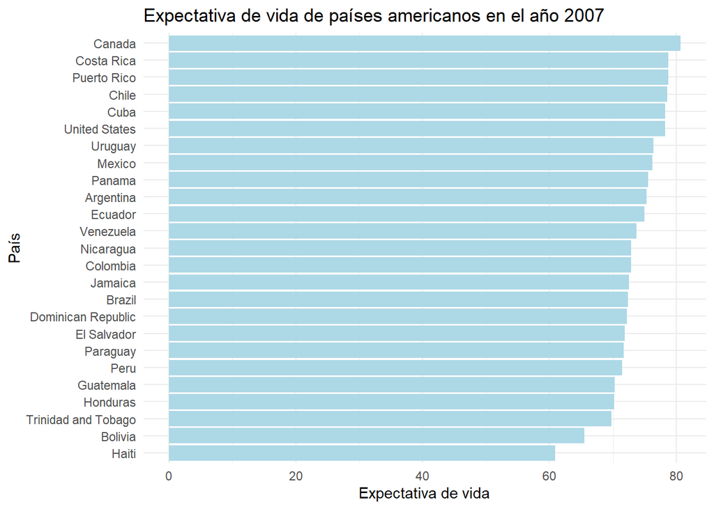

```r
df_america_2007 <- gapminder %>%
  filter(continent=='Americas' & year=='2007') %>%
  arrange(lifeExp) %>%  #Ordenar el data frame con la variable lifeExp
  mutate(country = factor(country, levels = country)) #Volver country factor para que conserve el orden

grafico_barras <- ggplot(df_america_2007, aes(x=country, y=lifeExp)) +
  geom_bar(stat = 'identity', fill= 'lightblue') +
  labs(x = 'País', y = 'Expectativa de vida',
       title = 'Expectativa de vida de países americanos en el año 2007') +
  coord_flip() +
  theme_minimal()

grafico_barras
```

Se puede usar la función colors() para ver una lista de todos los colores disponibles en R

```r
colors()
```

```
##   [1] "white"           "aliceblue"       "antiquewhite"    "antiquewhite1"
##   [5] "antiquewhite2"   "antiquewhite3"   "antiquewhite4"   "aquamarine"
##   [9] "aquamarine1"     "aquamarine2"     "aquamarine3"     "aquamarine4"
##  [13] "azure"           "azure1"          "azure2"          "azure3"
##  [17] "azure4"          "beige"           "bisque"          "bisque1"
##  [21] "bisque2"         "bisque3"         "bisque4"         "black"
##  [25] "blanchedalmond"  "blue"            "blue1"           "blue2"
##  [29] "blue3"           "blue4"           "blueviolet"      "brown"
##  [33] "brown1"          "brown2"          "brown3"          "brown4"
##  [37] "burlywood"       "burlywood1"      "burlywood2"      "burlywood3"
##  [41] "burlywood4"      "cadetblue"       "cadetblue1"      "cadetblue2"
##  [45] "cadetblue3"      "cadetblue4"      "chartreuse"      "chartreuse1"
##  [49] "chartreuse2"     "chartreuse3"     "chartreuse4"     "chocolate"
##  [53] "chocolate1"      "chocolate2"      "chocolate3"      "chocolate4"
##  [57] "coral"           "coral1"          "coral2"          "coral3"
##  [61] "coral4"          "cornflowerblue"  "cornsilk"        "cornsilk1"
##  [65] "cornsilk2"       "cornsilk3"       "cornsilk4"       "cyan"
##  [69] "cyan1"           "cyan2"           "cyan3"           "cyan4"
##  [73] "darkblue"        "darkcyan"        "darkgoldenrod"   "darkgoldenrod1"
##  [77] "darkgoldenrod2"  "darkgoldenrod3"  "darkgoldenrod4"  "darkgray"
##  [81] "darkgreen"       "darkgrey"        "darkkhaki"       "darkmagenta"
##  [85] "darkolivegreen"  "darkolivegreen1" "darkolivegreen2" "darkolivegreen3"
##  [89] "darkolivegreen4" "darkorange"      "darkorange1"     "darkorange2"
##  [93] "darkorange3"     "darkorange4"     "darkorchid"      "darkorchid1"
##  [97] "darkorchid2"     "darkorchid3"     "darkorchid4"     "darkred"
##  [ reached getOption("max.print") -- omitted 557 entries ]
```

Aunque también se puede usar cualquiera si escribe el código hexagesimal (ejemplo: #5f9ea0) puede encontrar más en https://www.color-hex.com/

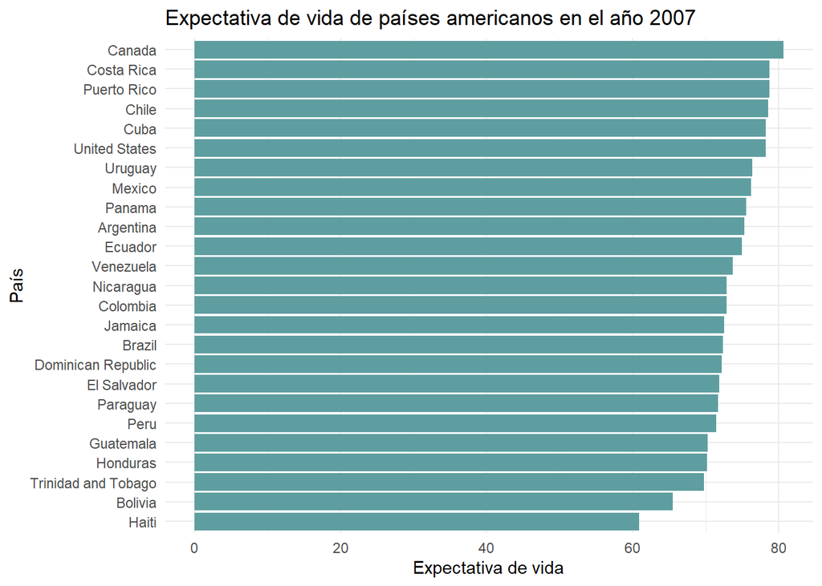

```r
grafico_barras <- ggplot(df_america_2007, aes(x=country, y=lifeExp)) +
  geom_bar(stat = 'identity', fill= '#5f9ea0') +
  labs(x = 'País', y = 'Expectativa de vida',
       title = 'Expectativa de vida de países americanos en el año 2007') +
  coord_flip() +
  theme_minimal()

grafico_barras
```

### 2.5.2 geom_line()

Se usa para dibujar gráficos de líneas. Estos usualmente sirven para visualizar series de tiempo.

Por ejemplo, podemos graficar la evolución de la expectativa de vida promedio de los países americanos en el tiempo.

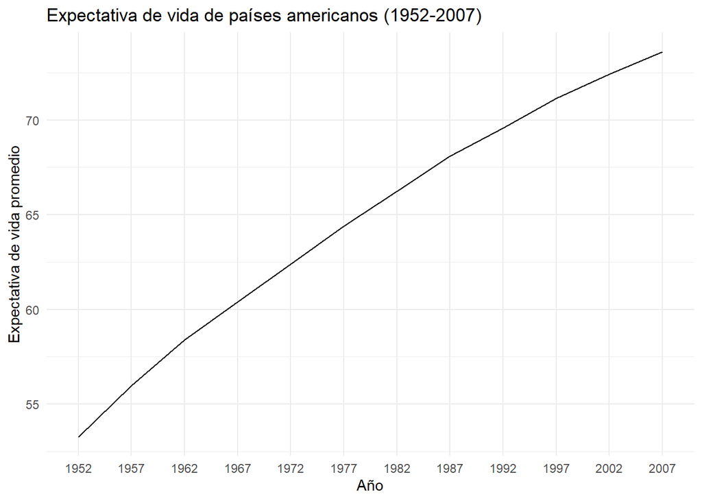

```r
df_america_lifeexp <- gapminder %>%
  filter(continent=='Americas') %>%
  group_by(year) %>%
  summarise(media_lifeExp = mean(lifeExp))

grafico_lineas <- ggplot(df_america_lifeexp, aes(x=year, y=media_lifeExp, group=1)) +
  geom_line() +
  labs(x = 'Año', y = 'Expectativa de vida promedio',
       title = 'Expectativa de vida de países americanos (1952-2007)') +
  theme_minimal()

grafico_lineas
```

Note que tuvimos que poner el aesthetic group=1 para que ggplot sepa que no hay agrupaciones.

Se puede combinar con geom_point() si se quiere marcar cada año.

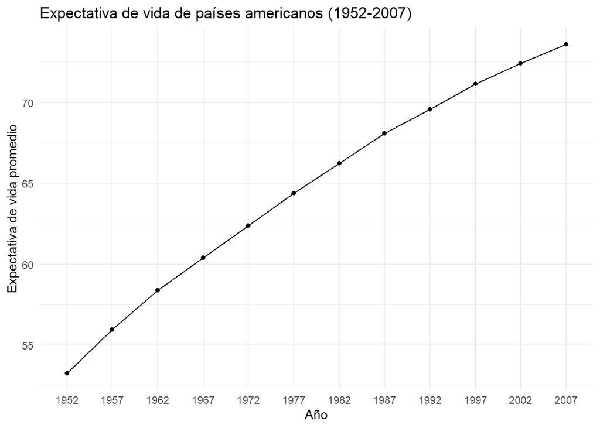

```r
grafico_lineas_puntos <- ggplot(df_america_lifeexp, aes(x=year, y=media_lifeExp, group=1)) +
  geom_line() +
  geom_point() +
  labs(x = 'Año', y = 'Expectativa de vida promedio',
       title = 'Expectativa de vida de países americanos (1952-2007)') +
  theme_minimal()

grafico_lineas_puntos
```

### 2.5.3 geom_text()

Esta geometría sirve para poner ‘etiquetas de datos’ en el gráfico. Se usa en conjunto con el aesthetic label.

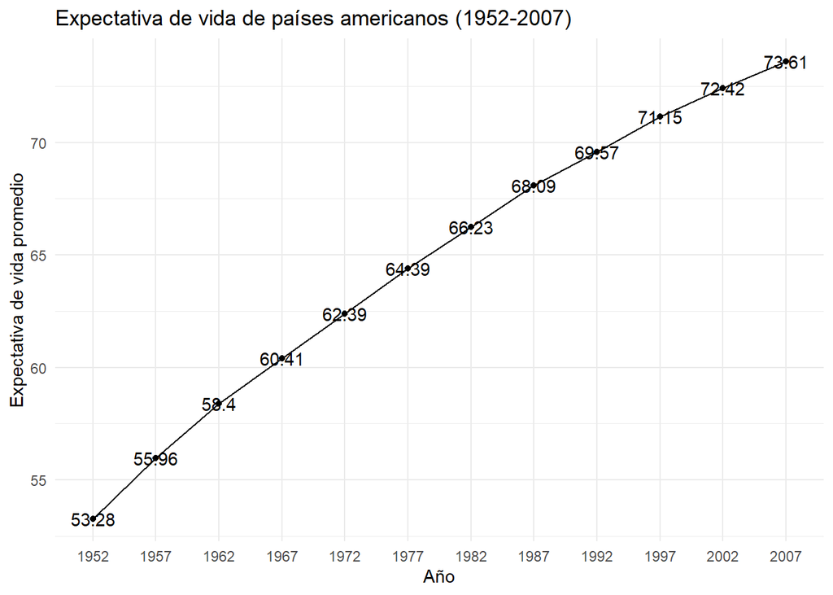

```r
grafico_lineas_puntos_texto <- ggplot(df_america_lifeexp,
                                      aes(x=year, y=media_lifeExp, group=1,
                                          label = round(media_lifeExp,2))) +
  geom_line() +
  geom_point() +
  geom_text() +
  labs(x = 'Año', y = 'Expectativa de vida promedio',
       title = 'Expectativa de vida de países americanos (1952-2007)') +
  theme_minimal()

grafico_lineas_puntos_texto
```

Así no se ve muy bien, podemos moverlo hacia arriba (vjust) y bajarle el tamaño al texto (size).

Valores negativos en vjust mueven el texto hacia arriba y valores positivos hacia abajo.

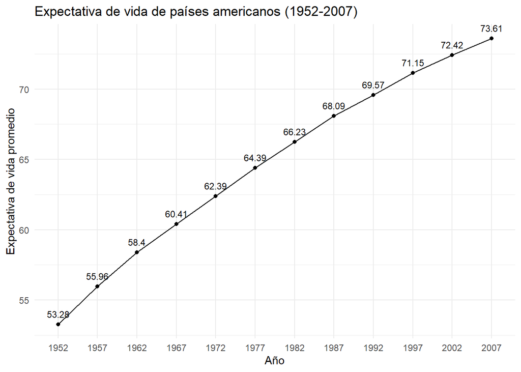

```r
grafico_lineas_puntos_texto <- ggplot(df_america_lifeexp,
                                      aes(x=year, y=media_lifeExp, group=1,
                                          label = round(media_lifeExp,2))) +
  geom_line() +
  geom_point() +
  geom_text(vjust=-1, size=3) +
  labs(x = 'Año', y = 'Expectativa de vida promedio',
       title = 'Expectativa de vida de países americanos (1952-2007)') +
  theme_minimal()

grafico_lineas_puntos_texto
```

### 2.5.4 geom_boxplot()

Como a veces la media no es suficiente, podemos usar el gráfico de cajas y bigotes para mostrar la mediana, los cuartiles 1 y 3 y hasta los valores atípicos (lo veremos en clase).

Para este gráfico no debemos modificar los datos, pues geom_boxplot() transforma los datos por nosotros. Solo filtraré para el continente americano.

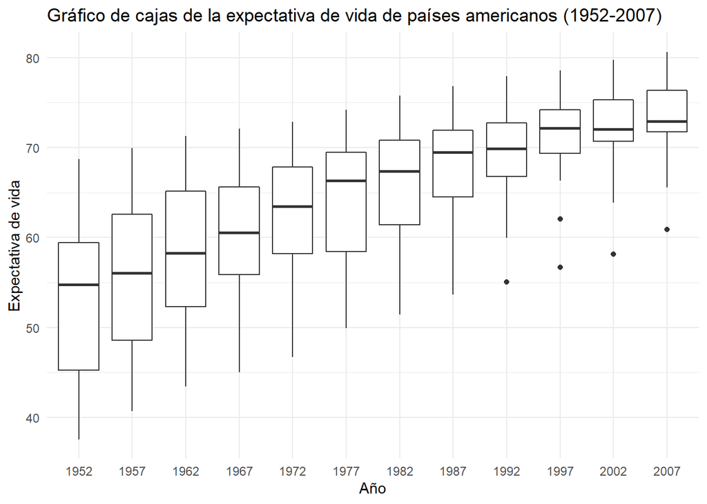

```r
df_america <- gapminder %>%
  filter(continent=='Americas')

grafico_cajas <- ggplot(df_america, aes(x=year, y=lifeExp)) +
  geom_boxplot() +
  labs(x = 'Año', y = 'Expectativa de vida',
       title = 'Gráfico de cajas de la expectativa de vida de países americanos (1952-2007)') +
  theme_minimal()

grafico_cajas
```

Podemos ver la misma tendencia hacia arriba en la mediana, pero adicionalmente estamos observando toda la distribución de los datos.

## 2.6 Aesthetics (ejes) más usados

Ya hemos visto algunos aesthetics adicionales, como group o label. Pero hacen falta otros importantes.

### 2.6.1 color

Este aesthetic se usa para mostrar una variable categórica como color de un gráfico de puntos o de líneas. Así no tenemos que dejar solo el continente americano.

Importante: Para el gráfico de líneas, el group debe tener la misma variable que el color.

```r
df_continents_lifeexp <- gapminder %>%
  group_by(year, continent) %>%
  summarise(media_lifeExp = mean(lifeExp))
```

[output not shown]

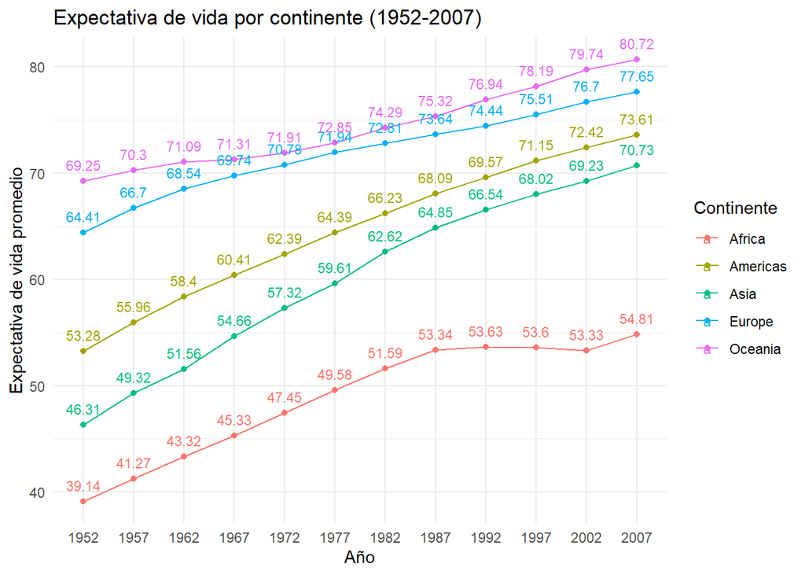

```r
grafico_lineas_color <- ggplot(df_continents_lifeexp,
                                      aes(x=year, y=media_lifeExp,color=continent, group=continent,
                                          label = round(media_lifeExp,2))) +
  geom_line() +
  geom_point() +
  geom_text(vjust=-1, size=3) +
  labs(x = 'Año', y = 'Expectativa de vida promedio', color='Continente',
       title = 'Expectativa de vida por continente (1952-2007)') +
  theme_minimal()

grafico_lineas_color
```

Este aes no se puede usar para las barras porque pinta el borde solamente. Por ello en ese caso usamos fill.

### 2.6.2 fill

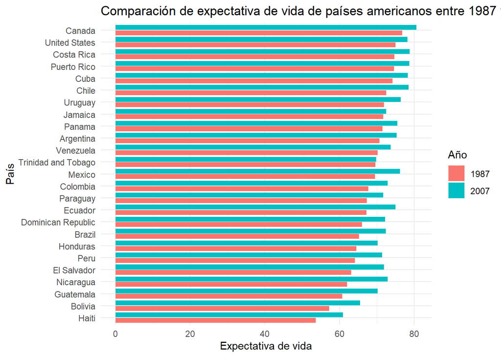

```r
df_america_1987_2007 <- gapminder %>%
  filter(continent=='Americas' & year %in% c('1987','2007')) %>%
  arrange(lifeExp) %>%  #Ordenar el data frame con la variable lifeExp
  mutate(country = factor(country, levels = unique(country))) #Volver country factor para que conserve el orden

grafico_barras_fill <- ggplot(df_america_1987_2007, aes(x=country, y=lifeExp, fill=year)) +
  geom_bar(stat = 'identity', position = position_dodge2(0.7)) +
  labs(x = 'País', y = 'Expectativa de vida', fill='Año',
       title = 'Comparación de expectativa de vida de países americanos entre 1987 y 2007') +
  coord_flip() +
  theme_minimal()

grafico_barras_fill
```

#### 2.6.2.1 Modificar los colores

Para modificar los colores se usa scale_fill_manual() o scale_color_manual(), dependiendo de que argumento se haya usado en aes().

El argumento values debe contener un vector con tantos colores como hay en la gráfica.

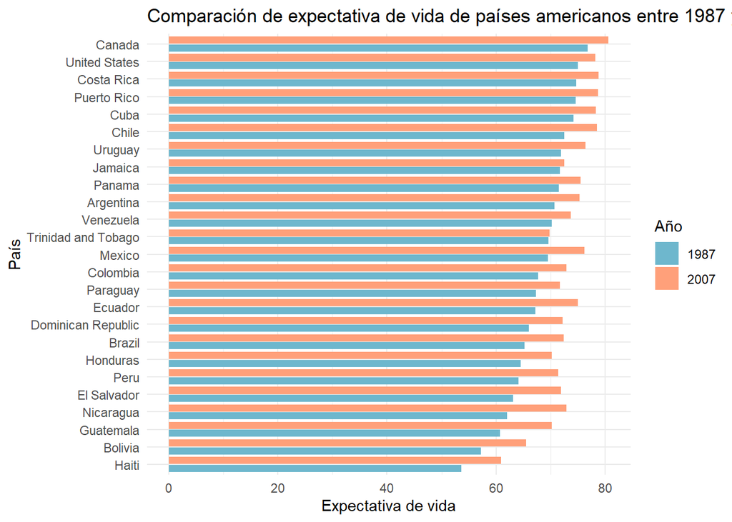

```r
grafico_barras_fill <- ggplot(df_america_1987_2007, aes(x=country, y=lifeExp, fill=year)) +
  geom_bar(stat = 'identity', position = position_dodge2(0.7)) +
  labs(x = 'País', y = 'Expectativa de vida', fill='Año',
       title = 'Comparación de expectativa de vida de países americanos entre 1987 y 2007') +
  scale_fill_manual(values = c('#6eb7cd', 'lightsalmon1')) +
  coord_flip() +
  theme_minimal()

grafico_barras_fill
```

## 2.7 Recursos ggplot2

En la galería de gráficos de R se pueden encontrar una gran cantidad de visualizaciones con código y ejemplos replicables. La dirección web es https://www.r-graph-gallery.com/ |